# Have you met Stan?

June 26, 2017

## What is Stan?

> Stan is freedom-respecting open-source software for facilitating statistical inference at the frontiers of applied statistics.

– Stan homepage

## Software for Bayesian inference

- Write-your-own sampler
- Purpose built routines for individual models
  - MCMCPack or bayesm in R
  - Stata's Bayesian package
  - Sawtooth CBC/HB
- Tools that automatically build samplers for a wide class of models
  - WinBugs
  - JAGS
  - **Stan**

## Fitting a hierarchical Bayes choice model with Stan

## Defining a model in Stan

- When you fit a model in Stan, you have to define the model using Stan's syntax.
- We don't have time to teach you the syntax, but we'll give you a quick peek at what a hierarchical Bayes multinomail logit model looks like.
- The is model is very similar to that estimated in Sawtooth CBC/HB and bayesm()

## Declare `data`

```stan
data {
  int<lower=2> C; // # of alternatives (choices) in each scenario
  int<lower=1> K; // # of covariates of alternatives
  int<lower=1> R; // # of respondents
  int<lower=1> S; // # of scenarios per respondent
  int<lower=0> G; // # of respondent covariates
  int<lower=1,upper=C> Y[R, S]; // observed choices
  matrix[C, K] X[R, S]; // matrix of attributes for each obs
  matrix[G, R] Z; // vector of covariates for each respondent
}
```

## Declare `parameters`

```stan
parameters {
  matrix[K, R] Beta;
  matrix[K, G] Theta;
  corr_matrix[K] Omega;
  vector<lower=0>[K] tau;
}
```

## Declare `transformed parameters`

```stan
transformed parameters {
  cov_matrix[K] Sigma = quad_form_diag(Omega, tau);
}
```

## Declare `model`

```stan
model {
  //priors
  to_vector(Theta) ~ normal(0, 10);
  tau ~ cauchy(0, 2.5);
  Omega ~ lkj_corr(2);
  //likelihood
  for (r in 1:R) {
    Beta[,r] ~ multi_normal(Theta*Z[,r], Sigma);
    for (s in 1:S)
      Y[r,s] ~ categorical_logit(X[r,s]*Beta[,r]);
  }
}
```

## Chocolate data in R

Data is formatted as a list with elements the same as those declared in the `data` block in the Stan model.

```r
str(choc.standata)
```

```
## List of 8
##  $ C: int 3
##  $ K: num 9
##  $ R: int 14
##  $ S: int 25
##  $ G: num 1
##  $ Y: int [1:14, 1:25] 1 2 2 2 3 1 2 2 2 3 ...
##  $ X: num [1:14, 1:25, 1:3, 1:9] 0.6 2.2 1.4 3.9 3 3.8 0.6 1.4 2.2 1.8 ...
##  $ Z: num [1, 1:14] 1 1 1 1 1 1 1 1 1 1 ...
```

## Bayesian inference

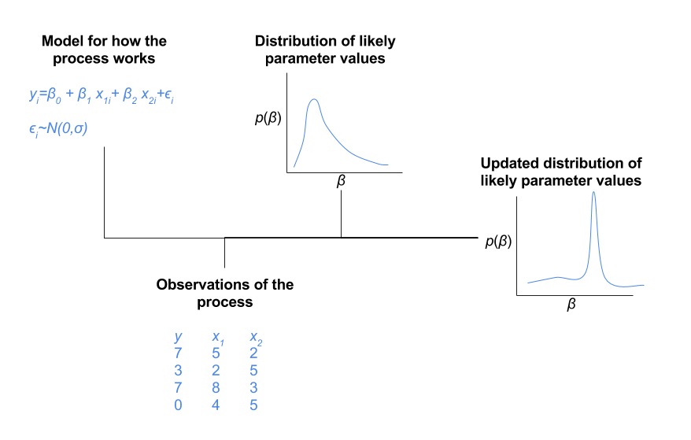

## Call the `stan()` function

```r
library(rstan)
choc.stan <- stan(file="hmnl.stan", data=choc.standata)
```

[output not shown]

[output cut: 8 more lines]

[output not shown]

[output not shown]

[output not shown]

[output not shown]

[output not shown]

[output not shown]

[output not shown]

[output not shown]

[output not shown]

[output not shown]

[output not shown]

[output not shown]

[output not shown]

[output not shown]

[output not shown]

[output not shown]

[output not shown]

[output not shown]

## Parameter estimates (1)

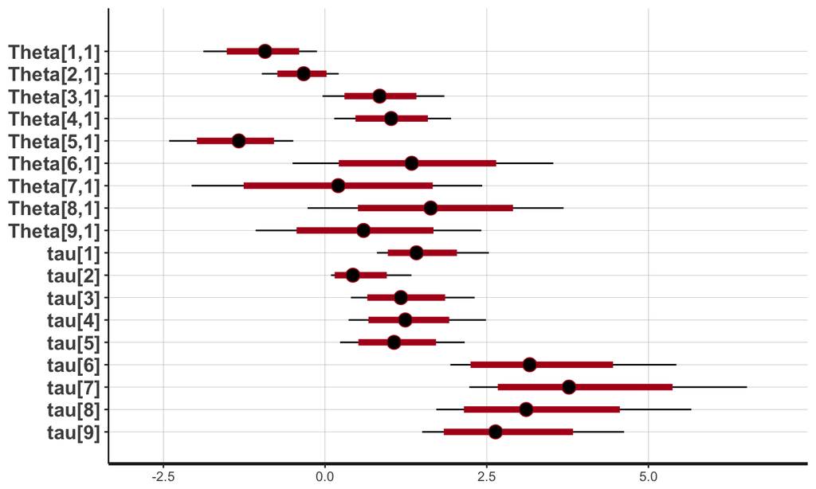

```r
plot(choc.stan, pars=c("Theta", "tau"))
```

## Parameter estimates (2)

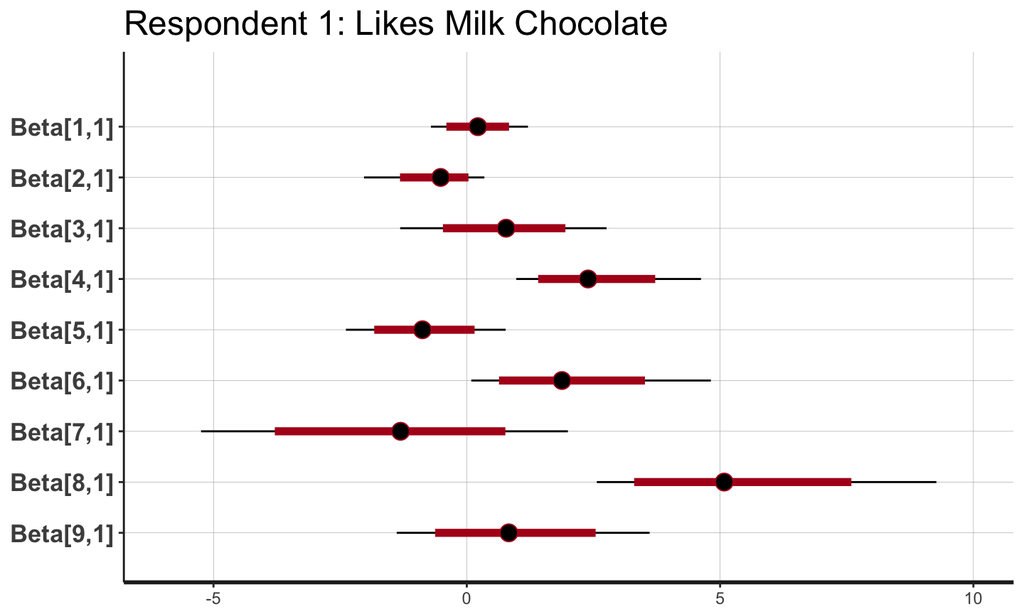

```r
plot(choc.stan, pars=paste("Beta[", 1:9, ",1]", sep="")) +
  ggtitle("Respondent 1: Likes Milk Chocolate")
```

## Parameter estimates (3)

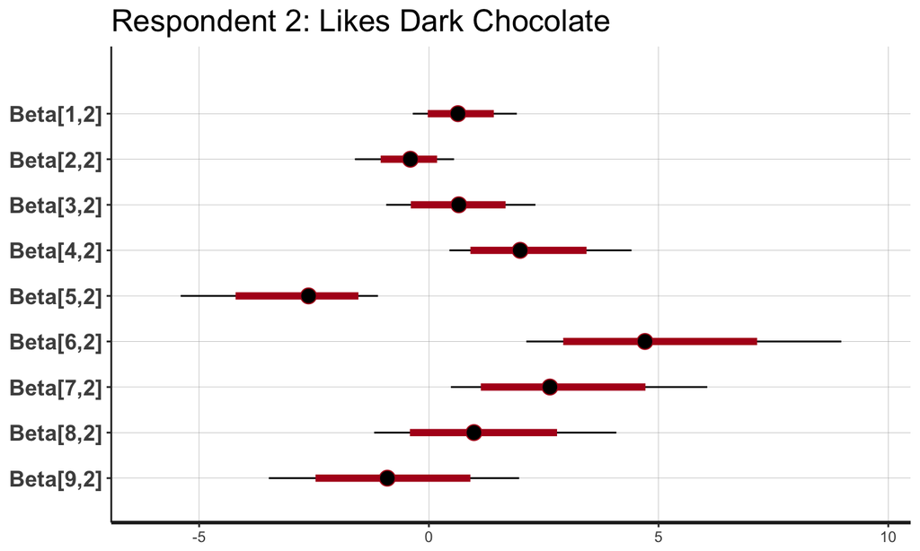

```r
plot(choc.stan, pars=paste("Beta[", 1:9, ",2]", sep="")) +
  ggtitle("Respondent 2: Likes Dark Chocolate")
```

## Simulating shares

- You can write a simulator in R to simulate shares.
- If you want a user interface for the simulator, try Shiny.

## Fitting other models in Stan

## Fitting other models in Stan

- The real power of Stan is that you can change the model to whatever you want.
- We have used Stan to fit:
  - Alternative priors (conjugacy isn't required!)
  - Hierarchcal nested logit model for dual choice
  - Dynamic linear models
  - Missing data models

## Problem: Shares in dual choice model

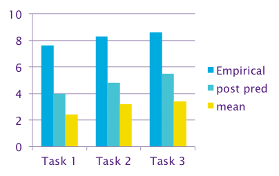

## HB nested logit Stan model

```stan
model {
  lambda ~ uniform(0, 1);
  sigma ~ normal(0, 5);
  to_vector(Theta) ~ normal(0, 10);
  to_vector(Epsilon) ~ normal(0, 1);
  matrix[K+1, R] Beta =
    Theta * Z + diag_pre_multiply(sigma, Epsilon);
  for (r in 1:R) {
    vector[K] b = Beta[2:(K+1), r];
    real alpha = Beta[1,r];
    for (s in 1:S) {
      vector[C] u = X[r,s] * b;
        real u_buy = alpha + lambda * log_sum_exp(u);
        Y1[r,s] ~ categorical_logit(u);
      Y2[r,s] ~ bernoulli_logit(u_buy);
    }
  }
}
```

## Problem solved

The nested logit model produces good predictions for the no-choice option in holdout tasks.

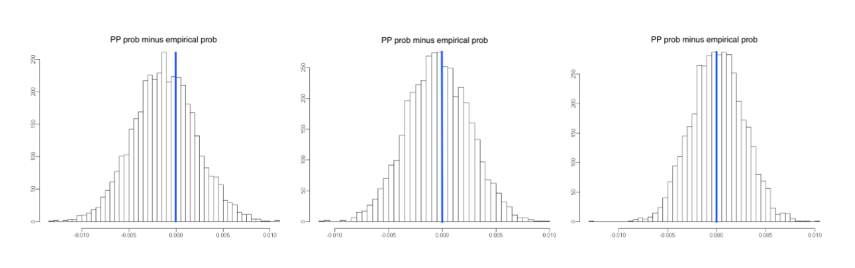

And building this model in Stan took hours, not days or weeks.

## A few more things you should know about Stan

## Who is responsible for Stan?

- Stan is maintained by the [Stan development team](http://mc-stan.org/about/team/index.html), which consistes of consists of volunteers from around the world.
- Key players include Andrew Gelman, Bob Carpenter, Michael Betancourt, but they have been joined by many others.

## There are many ways to interface with Stan

- **RStan (R)**
- PyStan (Python)
- CmdStan (shell, command-line terminal)
- MatlabStan (MATLAB)
- Stan.jl (Julia)
- StataStan (Stata)
- MathematicaStan (Mathematica)

## Stan supports multiple approches to inference

- Hamiltonian Monte Carlo / NUTS
  - Robust algorithm for Bayesian inference
- Variational Bayes
  - A fast approximation to full Bayesian inference
  - Somewhat experimental in Stan
- "Optimization"
  - Routines that find point estimates of parameters rather than the full posterior, e.g. maximum likelihood (ML) or maximum a posteriori (MAP)

## Why Stan?

- Ideal tool for rapid prototyping of new models
- Robust and fast sampler
- Modern, thoughful software design
- Increasingly attractive option for fitting even standard Bayesian models

## Thank you!

Thanks to The Modellers for sharing the code for the hierarchical nested logit model. Thanks to Adobe for their support.